# Merge Sort

Merge sort adalah algoritma pengurutan populer yang dikenal karena efisiensi dan stabilitasnya. Algoritma ini mengikuti pendekatan Divide and Conquer (bagi dan taklukkan). Cara kerjanya adalah dengan membagi array input secara rekursif menjadi dua bagian, mengurutkan kedua bagian tersebut secara rekursif, dan akhirnya menggabungkannya kembali untuk mendapatkan array yang sudah diurutkan.

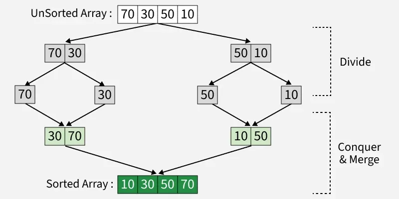

- Bagi: Bagi daftar atau larik secara rekursif menjadi dua bagian hingga tidak dapat dibagi lagi.
- Conquer: Setiap sub-array diurutkan secara individual menggunakan algoritma merge sort.
- Penggabungan: Subarray yang telah diurutkan digabungkan kembali dalam urutan yang telah diurutkan. Proses ini berlanjut hingga semua elemen dari kedua subarray telah digabungkan.

Mari kita urutkan array atau daftar [38, 27, 43, 10] menggunakan Merge Sort.

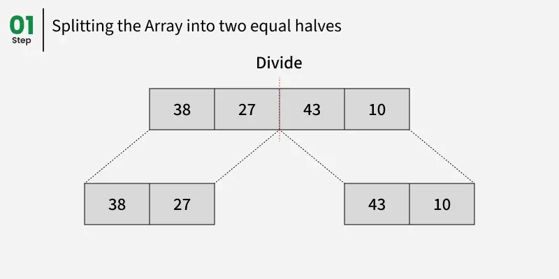

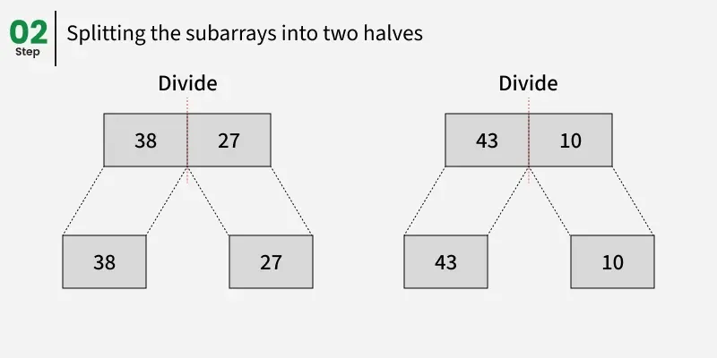

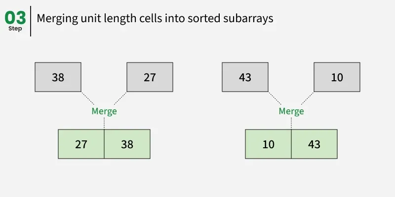

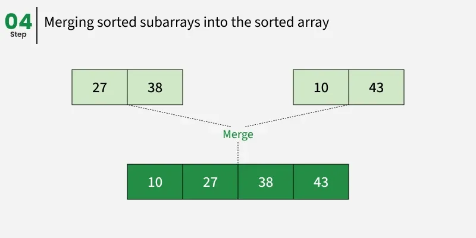

```
Cara kerja contoh di atas:

Divide:
[38, 27, 43, 10] dibagi menjadi [38, 27] dan [43, 10] .
[38, 27] dibagi menjadi [38] dan [27] .
[43, 10] dibagi menjadi [43] dan [10] .

Conquer:
[38] sudah diurutkan.
[27] sudah diurutkan.
[43] sudah diurutkan.
[10] sudah diurutkan.

Menggabungkan:
Gabungkan [38] dan [27] untuk mendapatkan [27, 38] .
Gabungkan [43] dan [10] untuk mendapatkan [10,43] .
Gabungkan [27, 38] dan [10, 43] untuk mendapatkan daftar terurut akhir [10, 27, 38, 43]
Oleh karena itu, daftar yang diurutkan adalah [10, 27, 38, 43] .
```

```python
def merge(arr, left, mid, right):
    n1 = mid - left + 1
    n2 = right - mid

    # Create temp arrays
    L = [0] * n1
    R = [0] * n2

    # Copy data to temp arrays L[] and R[]
    for i in range(n1):
        L[i] = arr[left + i]
    for j in range(n2):
        R[j] = arr[mid + 1 + j]

    i = 0
    j = 0
    k = left

    # Merge the temp arrays back
    # into arr[left..right]
    while i < n1 and j < n2:
        if L[i] <= R[j]:
            arr[k] = L[i]
            i += 1
        else:
            arr[k] = R[j]
            j += 1
        k += 1

    # Copy the remaining elements of L[],
    # if there are any
    while i < n1:
        arr[k] = L[i]
        i += 1
        k += 1

    # Copy the remaining elements of R[],
    # if there are any
    while j < n2:
        arr[k] = R[j]
        j += 1
        k += 1

def mergeSort(arr, left, right):
    if left < right:
        mid = (left + right) // 2

        mergeSort(arr, left, mid)
        mergeSort(arr, mid + 1, right)
        merge(arr, left, mid, right)

# Driver code
if __name__ == "__main__":
    arr = [38, 27, 43, 10]

    mergeSort(arr, 0, len(arr) - 1)
    for i in arr:
        print(i, end=" ")
    print()
```

```
10 27 38 43
```

#### Keuntungan dan Kerugian Merge Sort

Keuntungan

- Stabilitas : Merge sort adalah algoritma pengurutan yang stabil, yang berarti algoritma ini mempertahankan urutan relatif elemen-elemen yang sama dalam array input.
- Performa terburuk yang terjamin: Merge sort memiliki kompleksitas waktu terburuk O(N logN) , yang berarti ia berkinerja baik bahkan pada dataset besar.
- Mudah diterapkan: Pendekatan bagi-dan-taklukkan sangat mudah.
- Secara Alami Paralel : Kami menggabungkan sub-array secara independen sehingga cocok untuk pemrosesan paralel.

Kekurangan

- Kompleksitas ruang: Merge sort membutuhkan memori tambahan untuk menyimpan sub-array yang digabungkan selama proses pengurutan.
- Tidak in-place: Merge sort bukanlah algoritma pengurutan in-place, yang berarti algoritma ini membutuhkan memori tambahan untuk menyimpan data yang telah diurutkan. Hal ini dapat menjadi kerugian dalam aplikasi di mana penggunaan memori menjadi perhatian.
- Merge Sort umumnya lebih lambat daripada QuickSort karena QuickSort lebih ramah terhadap cache karena bekerja di tempat (in-place).